# handout devoir (2): elon musk a acquis twitter

st. schwarz

2025-06-01 06:56:21

# 1 A. head

Französisch GM3 / Roman Aubry / FUB SoSe25

download pdf [here](https://ada-sub.dh-index.org/school/papers/017/devoir-2-handout.pdf).

# 2 timeline

## 2.1 1

Le PDG de Tesla et de SpaceX, Elon Musk, est désormais le premier actionnaire du réseau social Twitter. Des documents publiés le 4 avril par le régulateur de la Bourse américaine montrent que M. Musk a acquis **9,2 % des actions du réseau social** , pour une **valeur d’environ 2,9 milliards de dollars (2,62 milliards d’euros)**.(Commission 2022) Ce rachat, effectué le 14 mars en toute discrétion par le multimilliardaire, a créé la surprise – la valeur de **l’action Twitter a grimpé** **de 27 % lundi** , à la Bourse de New York.  
Le 25 mars, l’entrepreneur polémiste a lancé un sondage : « La liberté d’expression est essentielle au fonctionnement de la démocratie. Croyez-vous que Twitter adhère rigoureusement à ce principe ? » Dans cette consultation sans valeur scientifique, le non l’a emporté à plus de 70 %. Dans la foulée, le fondateur de Tesla a demandé à ses fans ce qu’il convenait de tirer comme conséquences, voire s’il fallait « créer un nouveau réseau social ». (Q: Monde 2022a)

PDG=President Directeur Generale=CEO

Commission, United States Security and Exchange. 2022. “SCHEDULE 13G. CUSIP 90184L102.” Filing. https://www.sec.gov/Archives/edgar/data/1494730/000110465922041911/tm2211482d1_sc13g.htm.

Übernahme

geklettert

Monde, Le. 2022a. “Elon Musk Devient Le Premier Actionnaire de Twitter,” April. https://www.lemonde.fr/pixels/article/2022/04/04/elon-musk-devient-le-premier-actionnaire-de-twitter_6120535_4408996.html.

## 2.2 2

Le multimilliardaire Elon Musk propose de racheter Twitter, dont il est déjà le premier actionnaire, pour **41,39 milliards de dollars (37,9 milliards d’euros)** , comme le montre un document transmis mercredi au gendarme de la Bourse américaine et révélé jeudi 14 avril. Après cette annonce, le réseau social a annoncé qu’il allait « examiner avec attention » l’offre d’Elon Musk. M. Musk se dit prêt à débourser 54,20 dollars par action Twitter (49,70 euros). Cela représente un « premium », c’est-à-dire une bonification, de 21 % par rapport au cours d’ouverture du titre ce jeudi et de 54 % par rapport à celui du 28 janvier, date à laquelle M. Musk a commencé à investir dans Twitter. Le milliardaire a fait son entrée au capital du réseau social à hauteur de 9,2 %, comme l’ont montré des documents publiés le 4 avril par le régulateur de la Bourse américaine, la Securities and Exchange Commission. Twitter lui avait ensuite proposé d’entrer au conseil d’administration, ce qu’il avait refusé. (Q: Monde 2022b)

auszahlen

Monde, Le. 2022b. “Elon Musk Propose de Racheter Twitter,” April. https://www.lemonde.fr/pixels/article/2022/04/14/le-milliardaire-elon-musk-propose-de-racheter-twitter_6122149_4408996.html.

## 2.3 3

Twitter est désormais officiellement entre les mains d’Elon Musk, le patron de Tesla et de SpaceX, qui a conclu, **jeudi 27 octobre, l’acquisition du réseau social pour 44 milliards de dollars (44 milliards d’euros)** . « L’oiseau est libéré », a tweeté le milliardaire pour officialiser l’opération, ouvrant un nouveau chapitre incertain pour la plate-forme au cœur de la vie politique et médiatique des Etats-Unis et de nombreux pays. (Q: Monde 2022c)

Monde, Le. 2022c. “Elon Musk a Racheté Twitter Et Licencié Une Partie de Ses Dirigeants,” October. https://www.lemonde.fr/pixels/article/2022/10/28/elon-musk-rachete-twitter-et-licencie-une-partie-de-ses-dirigeants_6147637_4408996.html.

# 3 viz

Figure 3.1: twitter shares development

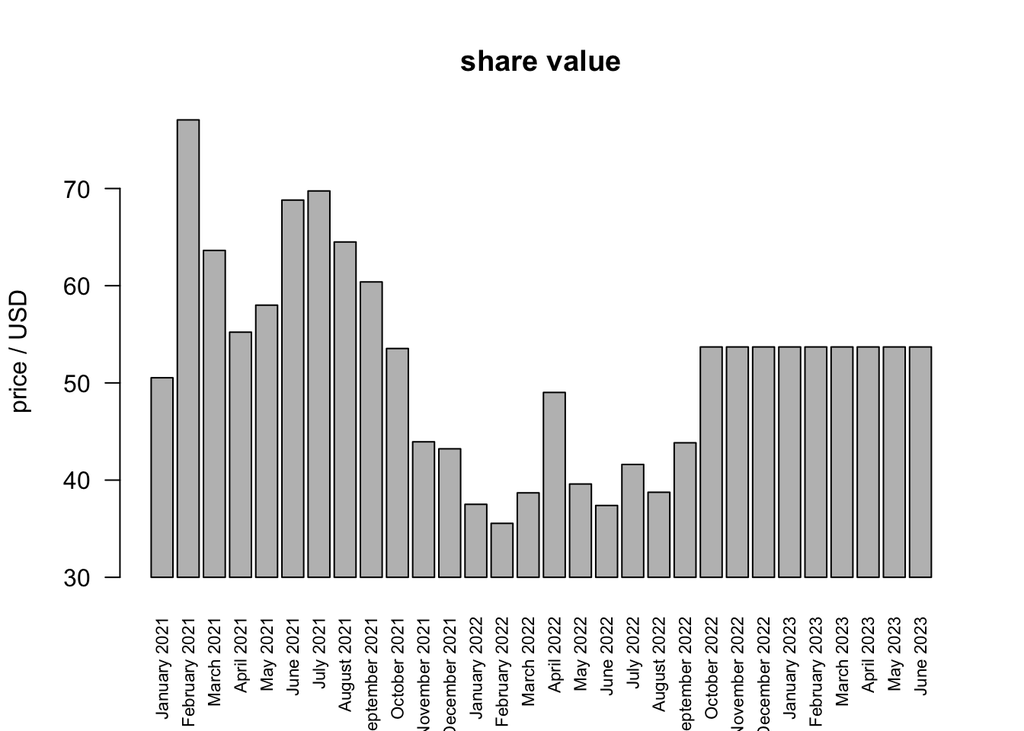

(Q: Digrin 2025)

Digrin. 2025. “Twitter, Inc. Price Digrin.” https://www.digrin.com/stocks/detail/TWTR/price.

# 4 impression personel

[figure not shown]

# 5 questions a course

- est-ce que votre utilisation du reseaux sociales a change apres cet evenement?
- est-ce que votre vie en generale est affecte par cet evenement?
- est-ce que vous avez faites des observations importants dans les reseaux sociales associé avec cet evenement?
- dans quelle sense a change la sphere societal politique a cause du cet evenement?
- survolez le premier paragraphe du (Q: Schenker and Grand 2022) et évaluez la question concernant les responsables du rachat au fin

  Schenker, Urs, and Caroline Grand. 2022. “Elon Musk Und Twitter – Der Schwierige Weg Zur Übernahme.” *Einzelheft «Schweizerische Zeitschrift Für Gesellschafts- Und Kapitalmarktrecht Sowie Umstrukturierungen»*, GesKR, 4/22 (Einzelheft «Schweizerische Zeitschrift für Gesellschafts- und Kapitalmarktrecht sowie Umstrukturierungen»): 501–7. https://www.walderwyss.com/assets/content/publications/221219_Elon-Musk-und-Twitter_der-schwierige-Weg-der-Uebernahme.pdf.

# 6 votre notes:

# B. REF: